# Lab 7: IRIS Classification

Let’s try something different this week! You should be familiar with the two-sample T test, ANOVA, simple linear regression, multiple linear regression and basic data visualization. Let’s move to statistical leaning! Don’t be afraid of the word “learning”, this is a good case study and dataset to begin an introduction to Machine Learning because it is so well understood.

- We will learn how to load and handle data.
- It is a classification problem, allowing us to experiment with various ML Algos
- It only has 4 attribute and 150 rows, meaning it is small and easily fits into memory.
- It gives an opportunity to apply many statistical learning algorithms

### Installing the required packages

We need to load a few important packages first to begin our analysis

#### *CARET Package*

The caret package provides a consistent interface into hundreds of machine learning algorithms and provides useful convenience methods for data visualization, data resampling, model tuning and model comparison, among other features. It’s a must have tool for machine learning projects in R. [Refer](http://topepo.github.io/caret/index.html)

#### *TIDYR Package:*

Is a new package that makes it easy to “tidy” your data. Tidy data is data that’s easy to work with: it’s easy to munge (*with* `dplyr`), visualise (*with* `ggplot2` or `ggvis`) and model (with R’s hundreds of modelling packages). The two most important properties of tidy data are:

- Each column is a variable.
- Each row is an observation.

Arranging your data in this way makes it easier to work with because you have a consistent way of referring to variables (as column names) and observations (as row indices). [Refer](https://blog.rstudio.org/2014/07/22/introducing-tidyr/)

```r
# install.packages("caret")
# install.packages("tidyr")
```

### Get the Data

#### *About the data set*

The Iris flower data set or Fisher’s Iris data set is a multivariate data set introduced by the British statistician and biologist Ronald Fisher in his 1936 paper. This is a very famous and widely used dataset by everyone trying to learn machine learning and statistics. The data set consists of 50 samples from each of three species of Iris (Iris setosa, Iris virginica and Iris versicolor). Four features were measured from each sample: the length and the width of the sepals and petals, in centimetres. The fifth column is the species of the flower observed. For more history of this dataset read here [Wikipedia](https://en.wikipedia.org/wiki/Iris_flower_data_set)

#### *Loading the data from within R*

```r
# Attach the dataset to the environment
data(iris)
# Get help on the data
help(iris)

# View the data
# View(iris)
```

#### *Splitting the Data into Training and Testing Sets*

This is one of the most important steps and concepts in Machine Learning. Before we do any meaningful work and learn from the dataset available to us, we need to split the dataset into `training set` and `testing set` and sometimes into a third `validation set`.

**TRAINING SET:** Is the `SEEN DATA` which is used to build and train the model. In classification problems such as this, we train the model using the classfication error rate: the percentage of incorrectly/correctly classified instances. We use the training data set to help us understand the data, select the appropriate model and determine model parameters.

**TESTING SET** This is the `UNSEEN DATA`. We build a model because we want to classify `new data`. We are also chiefly interested in the model performance(error rate) on this new data as it is more realistic estimate of the model fit in the real world.

**VALIDATION SET** Sometimes a part of the training set is split into the Validation Set to help us tune and optimize our models. It can be thought of as a Practice Testing set before we actually test the model using the TESTING SET

A good discussion of this topic can be found [here](https://stats.stackexchange.com/questions/19048/what-is-the-difference-between-test-set-and-validation-set)

```r
# Load the Caret package which allows us to partition the data
library(caret)
# We use the dataset to create a partition (80% training 20% testing)
index <- createDataPartition(iris$Species, p=0.80, list=FALSE)
# select 20% of the data for testing
testset <- iris[-index,]
# select 80% of data to train the models
trainset <- iris[index,]
```

Now that we have loaded and prepared our data for analysis, we are ready to move onto the next step which is `Exploring, Summarizing, Plotting and Understanding the Data`.

### Explore the Data

*Since we are dealing here with a clean and small dataset we are able to avoid the step of `Cleaning the data` which typically consumes a majority of the data scientists’ time.*

We explore the data to:

- Understand the data
- Summarize the data
- Clean and Prune the data
- Understand relationships between atrributes
- Think about and source other data which maybe useful in answering the question
- Get a preliminary feel for the types of models we think would best fit the data

#### Summarizing the Data

We begin by getting an idea of the attributes, dimensions and size of the data we are dealing with

```r
# Dimensions of the data
dim(trainset)
```

```
## [1] 120   5
```

```r
# Structure of the data
str(trainset)
```

```
## 'data.frame':    120 obs. of  5 variables:
##  $ Sepal.Length: num  5.1 4.9 5.4 5 4.4 4.9 5.4 4.8 4.8 4.3 ...
##  $ Sepal.Width : num  3.5 3 3.9 3.4 2.9 3.1 3.7 3.4 3 3 ...
##  $ Petal.Length: num  1.4 1.4 1.7 1.5 1.4 1.5 1.5 1.6 1.4 1.1 ...
##  $ Petal.Width : num  0.2 0.2 0.4 0.2 0.2 0.1 0.2 0.2 0.1 0.1 ...
##  $ Species     : Factor w/ 3 levels "setosa","versicolor",..: 1 1 1 1 1 1 1 1 1 1 ...
```

```r
# Summary of the data
summary(trainset)
```

```
##   Sepal.Length    Sepal.Width     Petal.Length    Petal.Width        Species
##  Min.   :4.300   Min.   :2.000   Min.   :1.000   Min.   :0.1   setosa    :40
##  1st Qu.:5.100   1st Qu.:2.800   1st Qu.:1.575   1st Qu.:0.3   versicolor:40
##  Median :5.800   Median :3.000   Median :4.300   Median :1.3   virginica :40
##  Mean   :5.849   Mean   :3.064   Mean   :3.745   Mean   :1.2
##  3rd Qu.:6.425   3rd Qu.:3.300   3rd Qu.:5.100   3rd Qu.:1.8
##  Max.   :7.900   Max.   :4.400   Max.   :6.700   Max.   :2.5
```

```r
# Levels of the prediction column
levels(trainset$Species)
```

```
## [1] "setosa"     "versicolor" "virginica"
```

### *Visualization and Exploration*

The advantage of a tool such as RStudio is that it allows a data scientist to creatively and quickly explore data via visualization. There are many powerful packages and tools in R such as `GGPLOT2`, etc which can be used to explore data as well as produce publishing quality plots to be used in reports and presentations. Here we will use some of these to explore and understand our dataset better

#### *Grammer of Graphics GGPLOTs*

ggplot2 is a very powerful package built on the concept of `"Grammar of Graphics (gg)"`. It allows you to **build** a plot following a particular syntax. It produces more aesthetically pleasing, more powerful plots than base graphics using more compact code for plot of similar complexity. You can read and understand more about ggplot [here](https://opr.princeton.edu/workshops/Downloads/2015Jan_ggplot2Koffman.pdf) and [here](http://tutorials.iq.harvard.edu/R/Rgraphics/Rgraphics.html). A cheatsheet for ggplot is available [here](https://www.rstudio.com/wp-content/uploads/2015/03/ggplot2-cheatsheet.pdf)

## **Q1: Please reproduct the following plots using ggplot2**

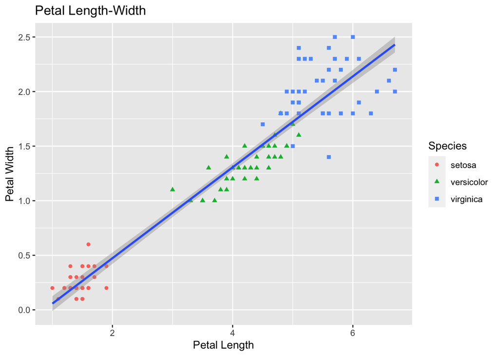

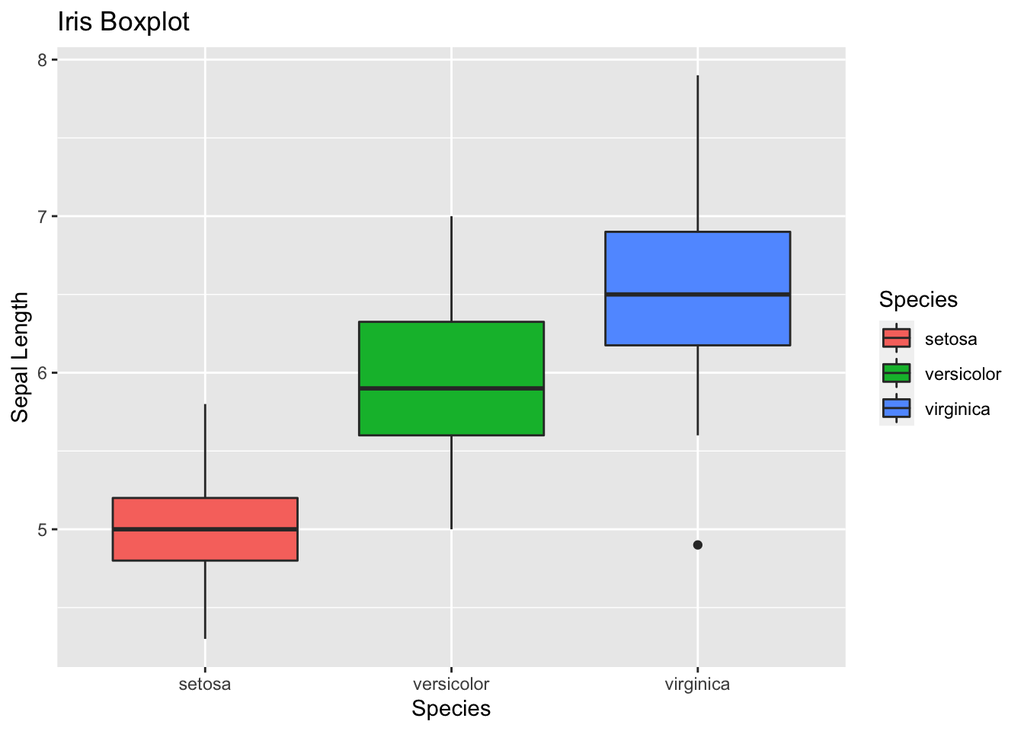

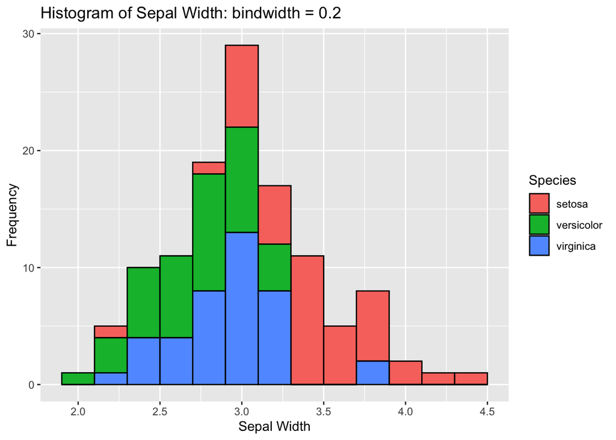

```r
# begin by loading the library
library(ggplot2)
```

You’ve used `facet_wrap` function before. Now, please add `facet_wrap(.~Species)` function to the scatter plot, and have the scatter plot with linear regression line added by ‘Species’.

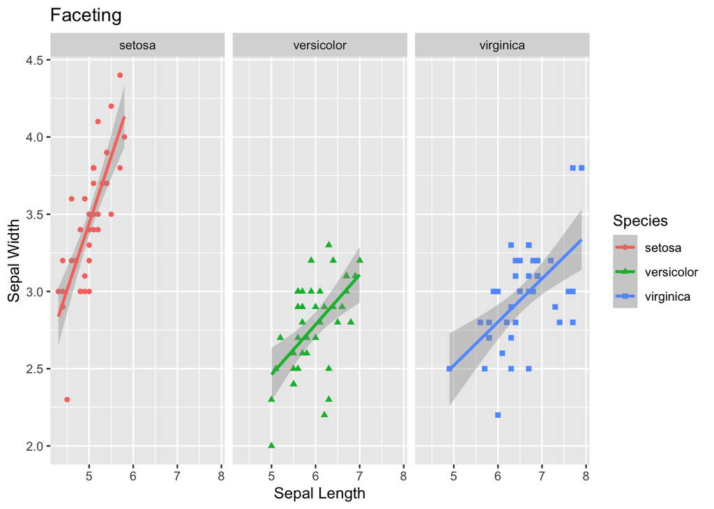

### *Getting Started with Statistical Learning*

Now that we have loaded the data and explored it to get a basic understanding of the relationships between the attributes, we can move to the next step which is **`Model Building`**.

> **The Problem:** *Given a set of data about the flowers (column 1 through 4) can we predict which of the 3 classes of flowers it belongs to.*

We will build and fit a discriminant models to the training set and try to learn from the `trainset` data. This is machine learning. We will later use the best model selected (or even a combination of models) to predict the classification for the `testset`. We will then measure how well our model is expected to perform in the real world.

Statistical learning itself can broadly be divided into two different fields:

- *Supervised Learning* defined as a set of tools used for prediction (linear model, logistic regression, linear discriminant analysis, classification trees, support vector machines and more)
- *Unsupervised Learning*, also known as `clustering`, is an exploratory data analysis technique used for identifying groups (i.e clusters) in the data set of interest. Each group contains observations with similar profile according to a specific criteria. Similarity between observations is defined using some inter-observation distance measures including Euclidean and correlation-based distance measures.

#### *Linear Discriminant Analysis*

Our last model will be the model to explain which Ronald Fisher originally used the Iris dataset. More information about this algorithm can be obtained [here](http://www.cs.ukzn.ac.za/~hughm/dm/content/slides08.pdf).

Linear Discriminant Analysis model is generally used for small data sets which would otherwise suffer from small sample bias in other models. Other classes of models might not be able to pick the trends in the data correctly, so for smaller datasets, a probability based classifier such as bayesian classifiers and lda are more suitable

Linear Discriminant Analysis (LDA) is also most commonly used as dimensionality reduction technique in the pre-processing step for pattern-classification and machine learning applications. The goal is to project a dataset onto a lower-dimensional space with good class-separability in order avoid overfitting (‘curse of dimensionality’) and also reduce computational costs. A good discussion of this (although in Python) can be found [here](http://sebastianraschka.com/Articles/2014_python_lda.html)

To use this model on our dataset we can go back to using the `CARET` package

```r
library(caret)
#install.packages("MASS")
library(MASS)
```

`set.seed` function will specify the way `R` generates the random number. Everyone with the same random seed should be able to reproduce your work and get exactly the same result.

```r
set.seed(20)
```

```r
# Fit the model
model.lda<-train(x = trainset[,1:4],y = trainset[,5], method = "lda",metric = "Accuracy")
# Print the model
print(model.lda)
```

```
## Linear Discriminant Analysis
##
## 120 samples
##   4 predictor
##   3 classes: 'setosa', 'versicolor', 'virginica'
##
## No pre-processing
## Resampling: Bootstrapped (25 reps)
## Summary of sample sizes: 120, 120, 120, 120, 120, 120, ...
## Resampling results:
##
##   Accuracy   Kappa
##   0.9714711  0.956585
```

We can check the accuracy on the training set. But please note: since your model was “learning under supervision from the training set”, the classification results on training set should be **very accurate**. `predict` function, similar to what you had in linear regression, will give the predicted species for a given observation.

However, to test the accuracy of the model, we need to test on testing data.

```r
## Verify the accuracy on the training set

pred<-predict(object = model.lda,newdata = trainset[,1:4])
confusionMatrix(pred,trainset$Species)
```

```
## Confusion Matrix and Statistics
##
##             Reference
## Prediction   setosa versicolor virginica
##   setosa         40          0         0
##   versicolor      0         38         0
##   virginica       0          2        40
##
## Overall Statistics
##
##                Accuracy : 0.9833
##                  95% CI : (0.9411, 0.998)
##     No Information Rate : 0.3333
##     P-Value [Acc > NIR] : < 2.2e-16
##
##                   Kappa : 0.975
##
##  Mcnemar's Test P-Value : NA
##
## Statistics by Class:
##
##                      Class: setosa Class: versicolor Class: virginica
## Sensitivity                 1.0000            0.9500           1.0000
## Specificity                 1.0000            1.0000           0.9750
## Pos Pred Value              1.0000            1.0000           0.9524
## Neg Pred Value              1.0000            0.9756           1.0000
## Prevalence                  0.3333            0.3333           0.3333
## Detection Rate              0.3333            0.3167           0.3333
## Detection Prevalence        0.3333            0.3167           0.3500
## Balanced Accuracy           1.0000            0.9750           0.9875
```

Let us now verify how it performs on the `testset` data in the real world

```r
## Performance on the test set
pred_test<-predict(object = model.lda,newdata = testset[,1:4])
confusionMatrix(pred_test,testset$Species)
```

```
## Confusion Matrix and Statistics
##
##             Reference
## Prediction   setosa versicolor virginica
##   setosa         10          0         0
##   versicolor      0         10         1
##   virginica       0          0         9
##
## Overall Statistics
##
##                Accuracy : 0.9667
##                  95% CI : (0.8278, 0.9992)
##     No Information Rate : 0.3333
##     P-Value [Acc > NIR] : 2.963e-13
##
##                   Kappa : 0.95
##
##  Mcnemar's Test P-Value : NA
##
## Statistics by Class:
##
##                      Class: setosa Class: versicolor Class: virginica
## Sensitivity                 1.0000            1.0000           0.9000
## Specificity                 1.0000            0.9500           1.0000
## Pos Pred Value              1.0000            0.9091           1.0000
## Neg Pred Value              1.0000            1.0000           0.9524
## Prevalence                  0.3333            0.3333           0.3333
## Detection Rate              0.3333            0.3333           0.3000
## Detection Prevalence        0.3333            0.3667           0.3000
## Balanced Accuracy           1.0000            0.9750           0.9500
```

## **Q2: Now, instead of using 80% training and 20% testing, choose 70% of the data as training data and 30% as testing data. Apply the linear discriminant analysis on the training set, then use the testing set to test the accuracy. Attach the confusion matrix.**